# Introduction

### Simulation for Exact Form Test

Finally, we operate test for exact form test: \ We still use the previous series where $Y_i = X_i$, $X_{j, i} = X_{i-j}$: $$X_i = \sin(2\pi\frac{i}{n}) e^{-X_{i-1}^2} + \epsilon_{i}$$ (1) $\boldsymbol H_0: m_{j,0}(t, x) = \sin(2\pi t) e^{-x^2}$ \ (2) $\boldsymbol H_0: m_{j,0}(t, x) = \Big(\sin(2\pi t) + 1\Big) e^{-x^2}$

```python
sieve_obj.exact_form_test(null_function_1, 1)
```

```
('not reject', 0.18999999999999995)
```

```python
sieve_obj.exact_form_test(null_function_2, 1)
```

```
('reject', 0.0)
```

The results show that the second null hypothesis is rejected.\ And now we try 1000 trials, under $\alpha = 0.1$

```python
def series_generator_single(data, n):
    x_1 = data[0]
    yield x_1
    for i in range(1, n):
        x_1 = (math.sin(2 * np.pi * (i + 1) / n)) * math.exp(- x_1 ** 2) + data[i]
        yield x_1

def series_generator_matrix(n, m):
    np.random.seed(1)
    x = np.random.randn(m, n)
    return np.array([list(series_generator_single(x[i], n)) for i in range(m)])
```

```python
n = 1000
m = 1000
series_matrix = series_generator_matrix(n, m)
```

```python
def bootstrap_trial(data, func_type_time, func_type_series, mapping_type, alpha=0.05):
    test_list = []
    with trange(len(data)) as pbar:
        for i in pbar:
            sieve_obj2 = SieveOLS2D(data[i], data[i], func_type_time, func_type_series, mapping_type, b, c1, c2)
            test_list.append(sieve_obj2.exact_form_test(null_function_1, 1, alpha))
            simulated_type_I_error = sum([_[0] == 'reject' for _ in test_list]) / len(test_list)
            pbar.set_description("Simulated Type I Error={}".format(simulated_type_I_error))
    return test_list
```

```python
test_list1 = bootstrap_trial(series_matrix, 'triangle', 'legendre', 'algebraic', alpha=0.1)
```

```python
sum([_[1] < 0.05 for _ in test_list1])
```

```
75
```

The simulated type I error is 0.154 for $\alpha = 0.1$ and 0.075 for $\alpha = 0.05$

# Real Dataset

## ABML Time Series

```python
ABML_df = pd.read_csv('series-250822.csv')
ABML_time_series = ABML_df[ABML_df.columns[1]][81: 304].to_numpy().astype(float)
ABML_second_diff = np.diff(np.diff(ABML_time_series))
```

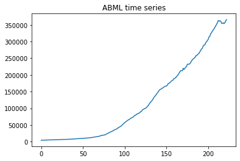

```python
plt.plot(np.arange(len(ABML_time_series)), ABML_time_series)
plt.title('ABML time series')
plt.show()
```

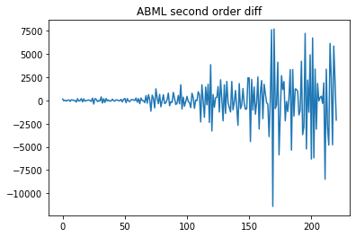

```python
plt.plot(np.arange(len(ABML_second_diff)), ABML_second_diff)
plt.title('ABML second order diff')
plt.show()
```

use orthogonal polynomials

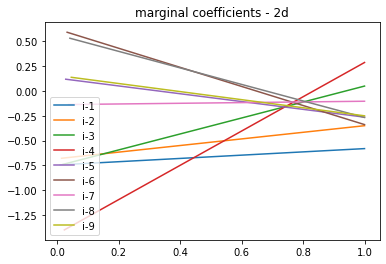

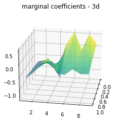

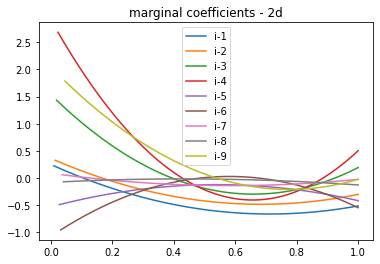

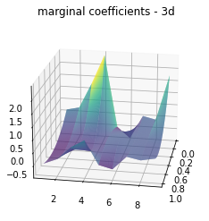

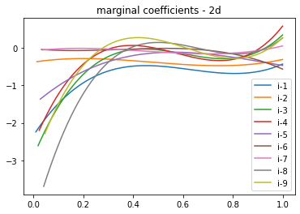

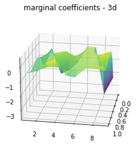

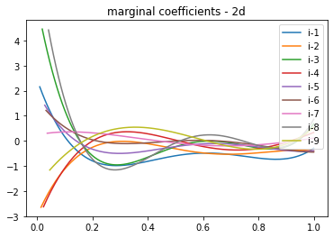

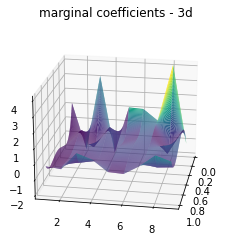

```python
for c_index in range(2, 6):
    ABML_obj = SieveOLS(ABML_second_diff, 'legendre', 2, c_index)
    ABML_obj.choose_b_intuitive()
```

use Fourier series

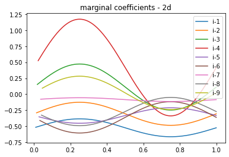

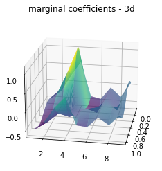

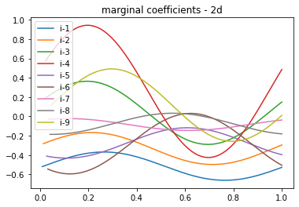

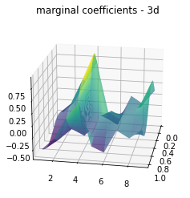

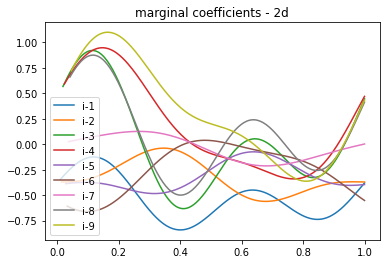

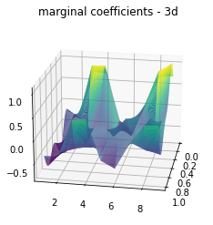

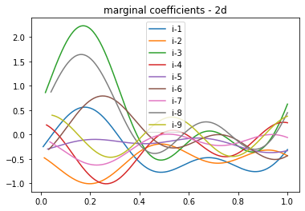

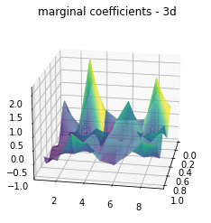

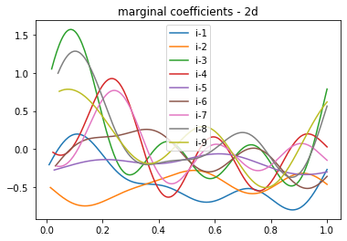

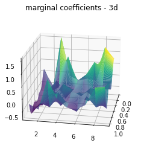

```python
for c_index in range(2, 7):
    ABML_obj = SieveOLS(ABML_second_diff, 'triangle', 2, c_index)
    ABML_obj.choose_b_intuitive()
```

use orthogonal wavelets

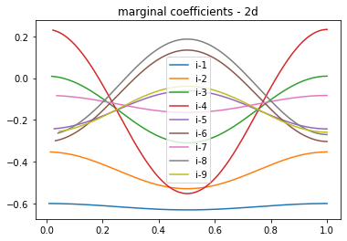

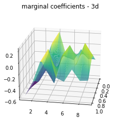

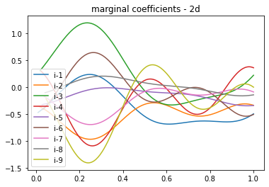

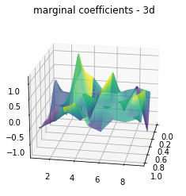

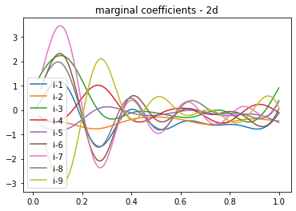

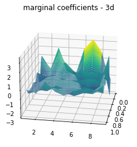

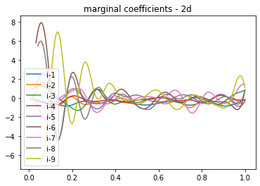

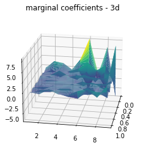

```python
for c_index in range(1, 5):
    ABML_obj = SieveOLS(ABML_second_diff, 'db16', 2, c_index)
    ABML_obj.choose_b_intuitive()
```